# Supplemental_figures

Stephanie Hickey

7/2/2022

## Set up

### Load packages etc.

```r
knitr::opts_chunk$set(echo = TRUE)
library(tidyverse)
library(patchwork)
library(parallel)
library(ggpubr)
library(rstatix)
source("./src/chronic_inflammation_functions.R")
figure_path = "./results/prediction_clusters_same_graph/figures"
if(!dir.exists(figure_path)){dir.create(figure_path)}
```

### Labeling trait types for the rest of the Figures & Tables

```r
# get complex vs ai labels
c_v_ai = read.csv("./data/diseases_used_in_study.csv", row.names = 1)

#Autoimmune diseases
ai =
  c_v_ai %>%
  filter(TraitType == "Autoimmune Disease") %>%
  pull(Disease)

#Complex diseases
complex =
  c_v_ai %>%
  filter(TraitType == "Complex Disease") %>%
  pull(Disease)
```

## Supplemental Table S1: Disease and trait Geneplexus average log2(auPRC/prior) from 3-fold cross validation

Results from `summarizeGeneplexusPredictions.R`

```r
load("./results/GenePlexus_parameter_checks/Geneplexus_summary_new_networks.Rdata")

# we did not use these in the analysis
remove_traits = c("Colitis","Height_gene_shot")

S1 =
  summary_df %>%
  dplyr::rename(PredictionNetwork = Network) %>%
  filter(!Disease %in% c(remove_traits, "chronic_inflammation_go"))

# save
write.csv(S1,
          file = paste0(figure_path, "/TableS1_CV_Scores.csv"),
          row.names = F)
```

## Supplemental Table S2: Disease and trait genes

```r
# load the disease genes from disgenet or pascal
files = list.files("./data/disease_gene_files",
                   pattern = ".txt",
                   full.names = TRUE)

temp = lapply(files, read.delim)

dgdf = do.call(rbind, temp)

dgdf =
  dgdf %>%
  dplyr::rename(EntrezID = Gene) %>%
  filter(!Disease %in% remove_traits) %>%
  mutate(TraitType =
           case_when(Disease %in% ai ~ "Autoimmune Disease",
                     Disease %in% complex ~ "Complex Disease",
                     !Disease %in% c(ai, complex)  ~ "Non-disease Trait"))

# add gene symbol
symbols = entrez2symbol(as.character(dgdf$EntrezID))
dgdf$GeneSymbol = symbols

# rearrange cols
S2 =
  dgdf %>%
  select(GeneSymbol,
         EntrezID,
         Disease,
         TraitType)
# save
write.csv(S2,
          file = paste0(figure_path, "/TableS2_seed_genes.csv"),
          row.names = F)
```

## Supplemental Table S3: Gene/Cluster assignments

### Load gene to cluster assignment files

```r
loadClusters = function(cluster_path){

  files = list.files(cluster_path, full.names = T, pattern = ".csv")
  # remove fake trait clusters
  files = files[grep("Fake_", files, invert=TRUE)]
  # load
  clust_list = mclapply(files,
                      read.csv,
                      row.names = 1,
                      mc.cores = detectCores()-1)
  # bind list
  clust_df = do.call(rbind, clust_list)
  return(clust_df)
}

cluster_dir = "./results/prediction_clusters_same_graph/clusters/"

string = loadClusters(paste0(cluster_dir, "predicted_withSTRING--clustered_on_STRING"))
string_exp = loadClusters(paste0(cluster_dir, "predicted_withSTRING-EXP--clustered_on_STRING-EXP"))
string_string_exp = loadClusters(paste0(cluster_dir, "predicted_withSTRING--clustered_on_STRING-EXP"))
biogrid = loadClusters(paste0(cluster_dir, "predicted_withBioGRID--clustered_on_BioGRID"))
cpdb = loadClusters(paste0(cluster_dir, "predicted_withConsensusPathDB--clustered_on_ConsensusPathDB"))

# bind dfs together
clust_list = list(string, string_exp, string_string_exp, biogrid, cpdb)
clust_df = do.call(rbind, clust_list)

# mark inflammatory gene sets if any
inflamm = unique(clust_df$Disease[grep("inflamm", clust_df$Disease)])

# add trait type to the cluster df
clust_df =
  clust_df %>%
  mutate(TraitType =
           case_when(Disease %in% ai ~ "Autoimmune Disease",
                     Disease %in% complex ~ "Complex Disease",
                     Disease %in% inflamm ~ "Inflammation Gene Set",
                     !Disease %in% c(ai, complex, inflamm)  ~ "Non-disease Trait"))

remove_traits = c(inflamm,
                  "Colitis",
                  "Height_gene_shot")
clust_df =
  clust_df %>%
  filter(!Disease %in% remove_traits)
```

### Add GenePlexus prediction average 3-fold CV for each disease/prediction network combo

Also has number of seed genes. Filter for >= 15

```r
summary_df =
  summary_df %>%
  dplyr::rename(PredictionNetwork = Network) %>%
  filter(!Disease %in% remove_traits) %>%
  select(Disease,
         PredictionNetwork,
         CVscore,
         nSeeds,
         TraitType)

clust_df =
  clust_df %>%
  left_join(summary_df)
```

### Remove diseases/traits where no permuted traits clustered.

Without permuted traits with clusters with at least five genes we can’t compute overlap p-values.

```bash
# out files from submit_clusterRandomGenes.R
cd ./run/sbatches_clusterRandomGenes
grep -hnr --with-filename "number clustered" *STRING-EXP.out > STRING-EXP_number_clustered.txt
grep -hnr --with-filename "number clustered" *STRING.out > STRING_number_clustered.txt
grep -hnr --with-filename "number clustered" *BioGrid.out > BioGrid_number_clustered.txt
grep -hnr --with-filename "number clustered" *ConsensusPathDB.out > ConsensusPathDB_number_clustered.txt
```

```r
files = list.files("./run/sbatches_clusterRandomGenes",
                   pattern = "_number_clustered.txt",
                   full.names = T)

graph_name = gsub("_number_clustered.txt", "", basename(files))

nclust_list = lapply(files, read.delim, header = F, sep = " ")

for(i in 1:length(nclust_list)){

  nclust_list[[i]]$nFakesClustered = gsub("number clustered = ", "", nclust_list[[i]]$V2)
  nclust_list[[i]]$nFakesClustered = as.numeric(nclust_list[[i]]$nFakesClustered)
  nclust_list[[i]]$Disease = gsub(paste0("_",graph_name[i],".*"), "", nclust_list[[i]]$V1)
  nclust_list[[i]]$ClusterGraph = graph_name[i]
}

nclust =
  do.call(rbind, nclust_list) %>%
  select(ClusterGraph,
         nFakesClustered,
         Disease)

nclust =
  nclust %>%
  filter(!Disease %in% remove_traits) %>%
  mutate(TraitType =
           case_when(Disease %in% ai ~ "Autoimmune Disease",
                     Disease %in% complex ~ "Complex Disease",
                     Disease %in% inflamm ~ "Inflammation Gene Set",
                     !Disease %in% c(ai, complex, inflamm)  ~ "Non-disease Trait"))

nclust$ClusterGraph = gsub("BioGrid", "BioGRID", nclust$ClusterGraph)

# join with nclust
clust_df =
  clust_df %>%
  left_join(nclust)
```

### Merge with GenePlexus prediction scores

```r
pred_path = "./results/GenePlexus_output"
gp_files = list.files(pred_path, full.names = TRUE)
gp_files = gp_files[grep("--DisGeNet--predictions.tsv", gp_files)]
gp_files = gp_files[grep("inflamm", gp_files, invert = TRUE)]

gp_list = mclapply(gp_files,
                   read.delim,
                   mc.cores= detectCores()-1)

file_name_split = str_split(basename(gp_files), pattern = "--")
dis_names = unlist(lapply(file_name_split, function(x) x[[1]]))
prednet = unlist(lapply(file_name_split, function(x) x[[2]]))

for(i in 1:length(gp_list)){

  gp_list[[i]]$Disease = dis_names[i]
  gp_list[[i]]$PredictionNetwork = prednet[i]

}

gpdf = do.call(rbind, gp_list)
```

### Filter, arrange, and save

```r
S3 =
  clust_df %>%
  filter(nSeeds >= 15,
         CVscore >= 1,
         nFakesClustered > 0,
         !Disease %in% remove_traits) %>%
  dplyr::rename(nClusteredPermutations = nFakesClustered,
                Entrez = Gene) %>%
  left_join(gpdf) %>%
  dplyr::select(PredictionNetwork,
                ClusterGraph,
                Disease,
                TraitType,
                nClusteredPermutations,
                Cluster,
                Entrez,
                Symbol,
                Probability,
                GeneType)

write.csv(S3,
          file = paste0(figure_path, "/TableS3_gene_cluster_assignments.csv"),
          row.names = F)
```

## Supplemental Table S4: Chronic inflammation gene sets with GenePlexus predictions

```r
pred_path = "./results/GenePlexus_output"
ci_files = list.files(pred_path, pattern = "inflamm", full.names = TRUE)
ci_files = ci_files[grep("--GO--predictions.tsv", ci_files)]

ci_list = mclapply(ci_files,
                   read.delim,
                   mc.cores= detectCores()-1)

file_name_split = str_split(basename(ci_files), pattern = "--")
ci_names = unlist(lapply(file_name_split, function(x) x[[1]]))
prednet = unlist(lapply(file_name_split, function(x) x[[2]]))

for(i in 1:length(ci_list)){

  ci_list[[i]]$ChronicInflammationSource = ci_names[i]
  ci_list[[i]]$PredictionNetwork = prednet[i]

}

cidf = do.call(rbind, ci_list)

S4 =
  cidf %>%
  filter(!ChronicInflammationSource %in%
           c("chronic_inflammation_go",
           "chronic_inflammatory_response_GO2EG")) %>%
  mutate(GeneType = case_when(Class.Label == "P" ~ "seed",
                              Class.Label != "P" & Probability >= .80 ~ "predicted CI-associated",
                              Class.Label != "P" & Probability < .80 ~ "not likely CI-associated")) %>%
  select(-Name, -Class.Label)

write.csv(S4,
          file = paste0(figure_path, "/TableS4_CI_genes.csv"),
          row.names = F)
```

## Supplemental Table S5: CI-overlap results

```r
files =
  list.files("./results/prediction_clusters_same_graph/scores",
                   pattern = ".Rdata",
                   full.names = T)

res_list = lapply(files, loadRData)

res_list = lapply(res_list,
                  function(x){
                    x$ChronicInfThreshold = as.character(x$ChronicInfThreshold);
                    x
                  })

res_df = do.call(rbind, res_list)

# add TraitType to res_df
res_df =
  res_df %>%
  filter(!Disease %in% remove_traits) %>%
  mutate(TraitType =
           case_when(Disease %in% ai ~ "Autoimmune Disease",
                     Disease %in% complex ~ "Complex Disease",
                     !Disease %in% c(ai, complex)  ~ "Non-disease Trait"))

# add cv score
S5 =
  res_df %>%
  left_join(summary_df) %>%
  filter(CVscore >= 1,
         nSeeds >= 15)

colnames(S5) = c(
  "ChronicInflammationSource",
  "nChronicInflammationSourceGenes",
  "Cluster",
  "nClusterGenes",
  "nOverlap",
  "phyperPval",
  "Enrichment",
  "Disease",
  "ChronicInf",
  "ChronicInfThreshold",
  "ClusterGraph",
  "PredictionNetwork",
  "phyperFDR",
  "TraitType",
  "PermutedPval",
  "PermutedFDR",
  "nClustersFromPermutedSets",
  "CVscore",
  "nSeeds")

S5 =
  S5 %>%
  ungroup() %>%
  select(PredictionNetwork,
         ClusterGraph,
         ChronicInflammationSource,
         Disease,
         Cluster,
         nOverlap,
         nChronicInflammationSourceGenes,
         nClusterGenes,
         Enrichment,
         PermutedPval,
         PermutedFDR,
         nClustersFromPermutedSets)

write.csv(S5,
          file = paste0(figure_path, "/TableS5_CI_overlap_results.csv"),
          row.names = F)
```

## Supplemental Table S6: Number of diseases considered for CI overlap

We included a disease if it:

- had cv > 1 on the prediction network
- had clusters with at least 5 genes
- had at least 1 permuted gene list that has clusters with at least 5 genes

```r
# total diseases
disease_tally =
  summary_df %>%
  filter(nSeeds >= 15,
         TraitType != "Inflammation Gene Sets") %>%
  group_by(TraitType, PredictionNetwork) %>%
  tally(name = "nTotal")

# Traits in each category with CV score > 1
cv_tally =
  summary_df %>%
  filter(CVscore >= 1) %>%
  group_by(TraitType, PredictionNetwork) %>%
  tally(name = "nCV1") %>%
  arrange(PredictionNetwork)

disease_tally =
  left_join(disease_tally, cv_tally) %>%
  select(TraitType,
         PredictionNetwork,
         nTotal,
         nCV1)

# Traits that clustered
nClustered =
  clust_df %>%
  select(Disease,
         PredictionNetwork,
         ClusterGraph,
         TraitType) %>%
  distinct() %>%
  group_by(PredictionNetwork,
           ClusterGraph,
           TraitType) %>%
  tally(name= "nClustered")

# Traits that clustered with CV >=1
nClusteredCV1 =
  clust_df %>%
  filter(CVscore >=1) %>%
  select(Disease,
         PredictionNetwork,
         ClusterGraph,
         TraitType) %>%
  distinct() %>%
  group_by(PredictionNetwork,
           ClusterGraph,
           TraitType) %>%
  tally(name= "nClusteredCV1")

# n traits where at least one fake trait clustered
fakes_clustered_tally =
  nclust %>%
  filter(nFakesClustered > 0) %>%
  group_by(TraitType, ClusterGraph) %>%
  tally(name = "nFakesClustered") %>%
  arrange(ClusterGraph)

#Traits that clustered with CV >=1 and > 0 Fakes clustered
clust_df =
  clust_df %>%
  left_join(nclust)

nClusteredCV1Fakes =
  clust_df %>%
  filter(CVscore >=1,
         nFakesClustered > 0,
         ClusterGraph == "ConsensusPathDB",
         TraitType == "Non-disease Trait") %>%
  pull(Disease) %>% unique()

nClusteredCV1Fakes =
  clust_df %>%
  filter(CVscore >=1,
         nFakesClustered > 0) %>%
  select(Disease,
         PredictionNetwork,
         ClusterGraph,
         TraitType) %>%
  distinct() %>%
  group_by(PredictionNetwork,
           ClusterGraph,
           TraitType) %>%
  tally(name= "nClusteredCV1withFakes")

disease_tally =
  left_join(disease_tally, nClustered) %>%
  left_join(fakes_clustered_tally) %>%
  left_join(nClusteredCV1) %>%
  left_join(nClusteredCV1Fakes)

# Traits with clusters with at least 5 genes
nGenesPerCluster =
  clust_df %>%
  group_by(Disease,
           Cluster,
           PredictionNetwork,
           ClusterGraph,
           TraitType) %>%
  tally()

nClustered5 =
  nGenesPerCluster %>%
  filter(n >= 5) %>%
  ungroup() %>%
  select(-Cluster, -n) %>%
  distinct() %>%
  group_by(TraitType,
           PredictionNetwork,
           ClusterGraph) %>%
  tally(name = "nClustered5")

# Traits with clusters with at least 5 genes and CV >= 1
nGenesPerCluster =
  clust_df %>%
  filter(CVscore >=1) %>%
  group_by(Disease,
           Cluster,
           PredictionNetwork,
           ClusterGraph,
           TraitType) %>%
  tally()

nClustered5CV1 =
  nGenesPerCluster %>%
  filter(n >= 5) %>%
  ungroup() %>%
  select(-Cluster, -n) %>%
  distinct() %>%
  group_by(TraitType,
           PredictionNetwork,
           ClusterGraph) %>%
  tally(name = "nClustered5CV1")

# Traits with clusters with at least 5 genes and CV >= 1 and >0 clustered permuted traits
nGenesPerCluster =
  clust_df %>%
  filter(CVscore >=1,
         nFakesClustered > 0) %>%
  group_by(Disease,
           Cluster,
           PredictionNetwork,
           ClusterGraph,
           TraitType) %>%
  tally()

nClustered5CV1fakes =
  nGenesPerCluster %>%
  filter(n >= 5) %>%
  ungroup() %>%
  select(-Cluster, -n) %>%
  distinct() %>%
  group_by(TraitType,
           PredictionNetwork,
           ClusterGraph) %>%
  tally(name = "nClustered5CV1withFakes")

disease_tally =
  left_join(disease_tally, nClustered5) %>%
  left_join(nClustered5CV1) %>%
  left_join(nClustered5CV1fakes)

###Number of traits with CV >=1 that cluster with 100 iterations of the Leiden algorithm, and/or have at least one cluster containing >= 5 genes.

disease_tally =
  disease_tally %>%
  dplyr::rename(nPermutedClustersSize5 = nFakesClustered,
                      nClustersSize5 = nClustered5,
                      nFinal = nClustered5CV1withFakes) %>%
               select(-nClustered,
                      -nClusteredCV1,
                      -nClusteredCV1withFakes,
                      -nClustered5CV1)

write.csv(disease_tally, file = paste0(figure_path, "/TableS6.csv"))
S6 = disease_tally

knitr::kable(disease_tally)
```

| TraitType | PredictionNetwork | nTotal | nCV1 | ClusterGraph | nPermutedClustersSize5 | nClustersSize5 | nFinal |
| --- | --- | --- | --- | --- | --- | --- | --- |
| Autoimmune Disease | BioGRID | 10 | 6 | BioGRID | 10 | 8 | 5 |
| Autoimmune Disease | ConsensusPathDB | 10 | 9 | ConsensusPathDB | 10 | 10 | 9 |
| Autoimmune Disease | STRING | 10 | 10 | STRING | 10 | 10 | 10 |
| Autoimmune Disease | STRING | 10 | 10 | STRING-EXP | 10 | 10 | 10 |
| Autoimmune Disease | STRING-EXP | 10 | 9 | STRING-EXP | 10 | 10 | 9 |
| Complex Disease | BioGRID | 37 | 27 | BioGRID | 36 | 31 | 22 |
| Complex Disease | ConsensusPathDB | 37 | 30 | ConsensusPathDB | 36 | 37 | 30 |
| Complex Disease | STRING | 37 | 37 | STRING | 36 | 37 | 36 |
| Complex Disease | STRING | 37 | 37 | STRING-EXP | 36 | 37 | 36 |
| Complex Disease | STRING-EXP | 37 | 33 | STRING-EXP | 36 | 36 | 31 |
| Non-disease Trait | BioGRID | 106 | 15 | BioGRID | 96 | 59 | 5 |
| Non-disease Trait | ConsensusPathDB | 106 | 20 | ConsensusPathDB | 97 | 101 | 16 |
| Non-disease Trait | STRING | 106 | 95 | STRING | 97 | 104 | 90 |
| Non-disease Trait | STRING | 106 | 95 | STRING-EXP | 97 | 85 | 77 |
| Non-disease Trait | STRING-EXP | 106 | 38 | STRING-EXP | 97 | 99 | 32 |

## Supplemental Table S7: CI-signature group assignments

Only includes ConsensusPathDB clusters. See Fig3_TabS7_TabS8.Rmd

## Supplemental Table S8: GOBP enrichments for CI-signature groups

Only includes ConsensusPathDB clusters. See Fig3_TabS7_TabS8.Rmd

## Supplemental Table S9: SAveRUNNER results

Only includes ConsensusPathDB clusters. See Fig4_TabS9.Rmd

## Figure S1: Number of genes in each inflammation geneset

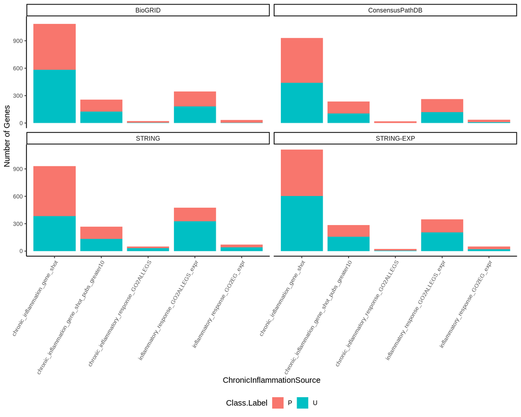

Fig. S1: Number of seed and Geneplexus predicted by each network in inflammation genes in each gene set

```r
P =
cidf %>%
  filter(Probability >= .80,
         !ChronicInflammationSource %in% c("chronic_inflammation_go",
                                           "chronic_inflammatory_response_GO2EG")) %>%
  ggplot(aes(x = ChronicInflammationSource,
             fill = Class.Label)) +
  geom_bar() +
  theme_classic() +
  theme(axis.text.x = element_text(angle = 60,
                                   hjust=1)) +
  theme(legend.position="bottom") +
  ylab("Number of Genes") +
  theme(axis.text = element_text(size = 8)) +
  facet_wrap(~PredictionNetwork, ncol = 2)

ggsave(P,
       file = paste0(figure_path,
                     "/FigS1_nChronicInflammation_seed_genes.png"),
       width = 7,
       height = 7,
       dpi = 300)

P
```

## Figure S2: Proportion of traits overlapping at least one chronic inflammation cluster

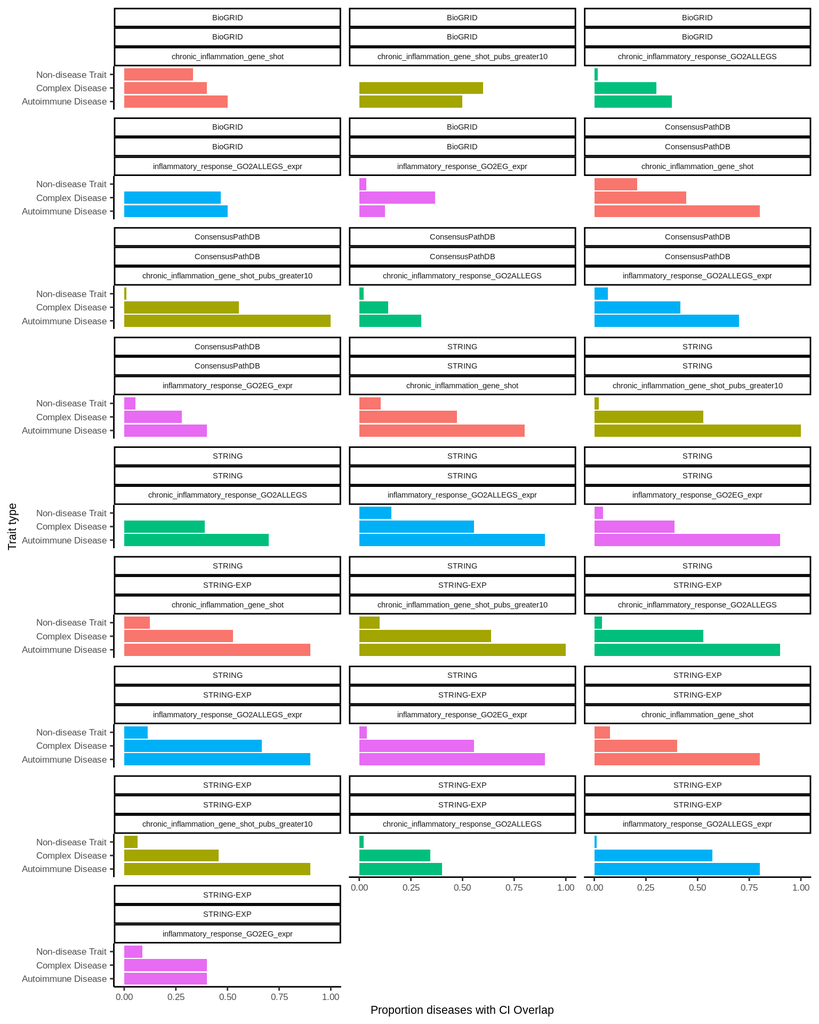

Fig S2: Proportion of traits with at least one CI-enriched cluster. The top network is the network used for Geneplexsus prediction, the bottom network was used for clustering

```r
res_list =
  res_df %>%
  group_by(Group1,
           PredictionNetwork,
           ClusterGraph) %>%
  group_split()

tallySigDiseases = function(df, cutoff){

  sig_disease =
    df %>%
    filter(PermutedFDR < cutoff,
           Enrichment > 0) %>%
    select(Disease,
           TraitType,
           PredictionNetwork,
           ClusterGraph,
           ChronicInfThreshold,
           Group1) %>%
    distinct() %>%
    mutate(Signficant_Overlap = "Yes")

  not_sig_diseases =
    df %>%
    filter(!Disease %in% sig_disease$Disease) %>%
    select(Disease,
           TraitType,
           PredictionNetwork,
           ClusterGraph,
           ChronicInfThreshold,
           Group1) %>%
    distinct() %>%
    mutate(Signficant_Overlap = "No")

  # bind
  sig_disease = rbind(sig_disease, not_sig_diseases)

  return(sig_disease)
}

sig_disease_list = lapply(res_list, tallySigDiseases, cutoff = .05)
sig_disease_df = do.call(rbind, sig_disease_list)

tally_sig_disease =
  sig_disease_df %>%
  group_by(TraitType,
           PredictionNetwork,
           ClusterGraph,
           Group1,
           Signficant_Overlap) %>%
  tally() %>%
  pivot_wider(names_from = Signficant_Overlap,
              values_from = n,
              values_fill = 0) %>%
  mutate(Total = Yes + No) %>%
  mutate(PropSig = Yes/Total)

# plot
tally_sig_disease$TraitType = factor(tally_sig_disease$TraitType,
                                   levels = c("Autoimmune Disease",
                                              "Complex Disease",
                                              "Non-disease Trait"))
Fig2a =
  tally_sig_disease %>%
  filter(!Group1 %in% c("chronic_inflammation_go",
                        "chronic_inflammatory_response_GO2EG")) %>%
  ggplot(aes(x = TraitType,
             y = PropSig,
             fill = Group1)) +
  geom_col() +
  theme_classic() +
  xlab("Trait type") +
  ylab("Proportion diseases with CI Overlap") +
  guides(fill = guide_legend("CI gene set")) +
  coord_flip() +
  theme(legend.position="none",
        text = element_text(size = 8),
        strip.text = element_text(size = 5.5),
        ) +
  facet_wrap(~PredictionNetwork + ClusterGraph + Group1,
             ncol = 3)

ggsave(Fig2a,
       file = paste0(figure_path,
                     "/FigS2_proportion_clustered_FDR05.png"),
       width = 7,
       height = 10,
       dpi = 300)

Fig2a
```

## Figure S3-S7: Chronic inflammation association score of non-seed genes in overlapping and non-overlapping clusters.

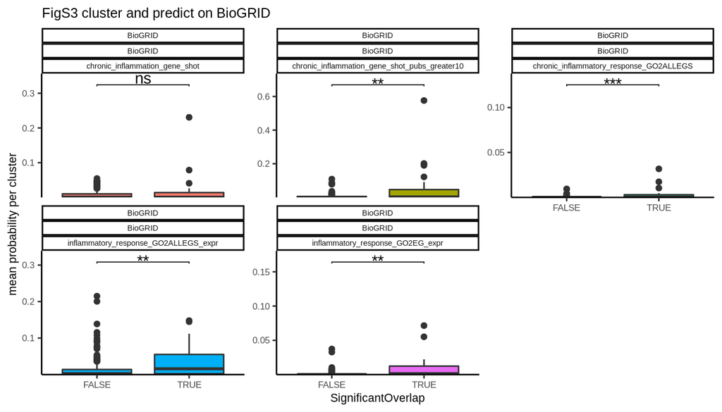

The top network is the network used for Geneplexsus prediction, the bottom network was used for clustering

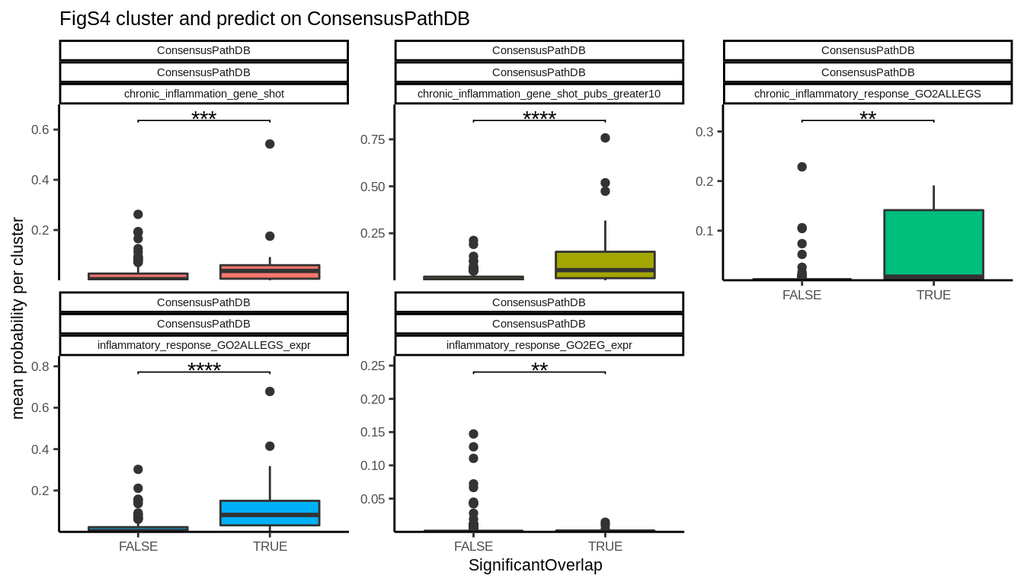

The top network is the network used for Geneplexsus prediction, the bottom network was used for clustering

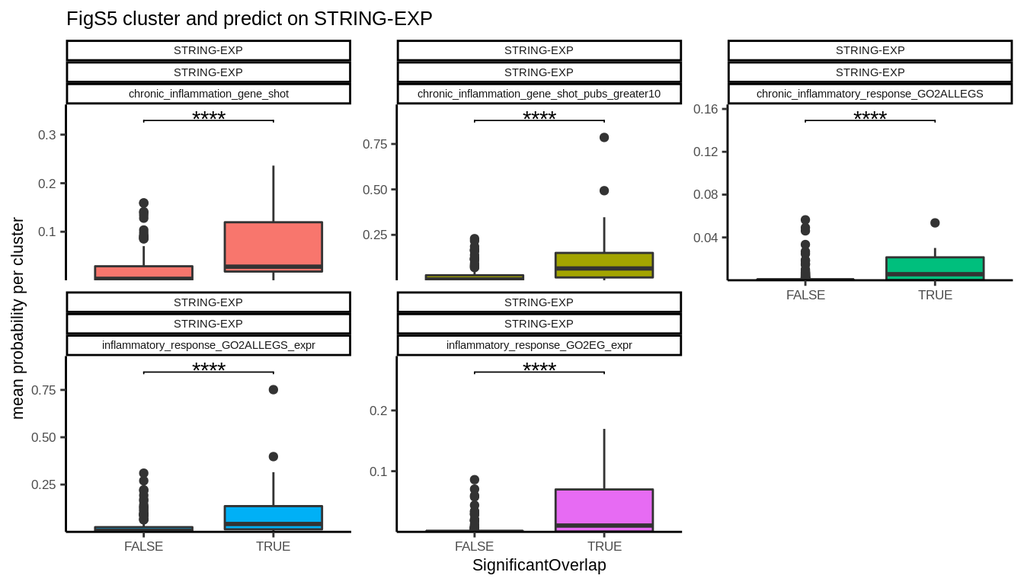

The top network is the network used for Geneplexsus prediction, the bottom network was used for clustering

```r
# merge overlap FDR with cluster assignments

res_clust =
  res_df %>%
  ungroup() %>%
  dplyr::rename(ChronicInflammationSource = Group1,
         Cluster = Group2) %>%
  left_join(clust_df) %>%
  select(Gene,
         Disease,
         Cluster,
         TraitType,
         PredictionNetwork,
         ClusterGraph,
         ChronicInflammationSource,
         ChronicInfThreshold,
         Enrichment,
         PermutedFDR) %>%
  mutate(SignificantOverlap =
           case_when(PermutedFDR > .05 | Enrichment < 0 ~ FALSE,
                     PermutedFDR <= .05 & Enrichment > 0 ~ TRUE)) %>%
  filter(!is.na(PermutedFDR)) # clusters with fewer than 5 genes

# merge with chronic inflammation GenePlexus predictions

cidf =
  cidf %>% # all predictions bound into one file
  select(Entrez,
         Probability,
         Class.Label,
         PredictionNetwork,
         ChronicInflammationSource) %>%
  dplyr::rename(Gene = Entrez)

clust_pred =
  left_join(res_clust, cidf) %>%
  mutate(CI_GeneType =
           case_when(ChronicInfThreshold == "P" & Class.Label == "P"  ~ "Seed",
                     ChronicInfThreshold == "P" & Class.Label != "P" ~ "not Seed",
                     ChronicInfThreshold == 0.8 & Probability >= 0.8 ~ "Seed",
                     ChronicInfThreshold == 0.8 & Probability < 0.8 ~ "not Seed"))

# merge with CVscores
clust_pred =
  left_join(clust_pred, summary_df)

clust_pred_mean =
  clust_pred %>%
  group_by(Cluster,
           ClusterGraph,
           PredictionNetwork,
           ChronicInflammationSource,
           ChronicInfThreshold,
           CI_GeneType) %>%
  mutate(MeanProb = mean(Probability)) %>%
  select(Cluster,
         TraitType,
         ClusterGraph,
         PredictionNetwork,
         ChronicInflammationSource,
         ChronicInfThreshold,
         CI_GeneType,
         MeanProb,
         SignificantOverlap,
         CVscore) %>%
  distinct()

# pvals
clust_pred_mean_filt =
  clust_pred_mean %>%
  filter(CI_GeneType == "not Seed",
         TraitType != "Non-disease Trait", # plot only real diseases
         !ChronicInflammationSource %in% c("chronic_inflammation_go",
                                           "chronic_inflammatory_response_GO2EG"))

clust_pred_mean_filt$SignificantOverlap = factor(clust_pred_mean_filt$SignificantOverlap,
                                            levels = c("FALSE",
                                                       "TRUE"))
pred_mean_wilcox =
  clust_pred_mean_filt %>%
  group_by(ClusterGraph,
           PredictionNetwork,
           ChronicInflammationSource) %>%
  wilcox_test(formula = MeanProb ~ SignificantOverlap,  p.adjust.method = "BH") %>%
  adjust_pvalue(method = "BH") %>%
  add_significance("p.adj") %>%
  add_y_position(formula = MeanProb ~ SignificantOverlap,
                   fun = "max")

# plot
n = 2
for(pn in unique(clust_pred_mean_filt$PredictionNetwork)){
if(pn == "STRING"){next}
n = n + 1
plot_p =
  pred_mean_wilcox %>%
  filter(PredictionNetwork == pn)

p1 =
  clust_pred_mean_filt %>%
  filter(PredictionNetwork == pn) %>%
  ggplot(aes(x = SignificantOverlap,
             y = MeanProb,
             fill = ChronicInflammationSource)) +
  geom_boxplot() +
  ylab("mean probability per cluster") +
  theme_classic() +
   theme(legend.position="none",
        text = element_text(size = 8),
        strip.text = element_text(size = 5.5),
        strip.text.x = element_text(margin = margin(.1, 0, .1, 0, "cm"))
        ) +
  facet_wrap(~PredictionNetwork + ClusterGraph + ChronicInflammationSource,
             ncol = 3, scales = "free_y") +
  stat_pvalue_manual(plot_p, label = "p.adj.signif", tip.length = 0.01) +
  scale_y_continuous(expand = expansion(mult = c(0, 0.1)))

ggsave(p1,
       file = paste0(figure_path,
                     "/FigS", n, "_mean_pred_non_seed_", pn, ".png"),
       width = 7,
       height = 4,
       dpi = 300)

plot(p1 + ggtitle(paste0("FigS", n, " cluster and predict on ", pn)))

}
```

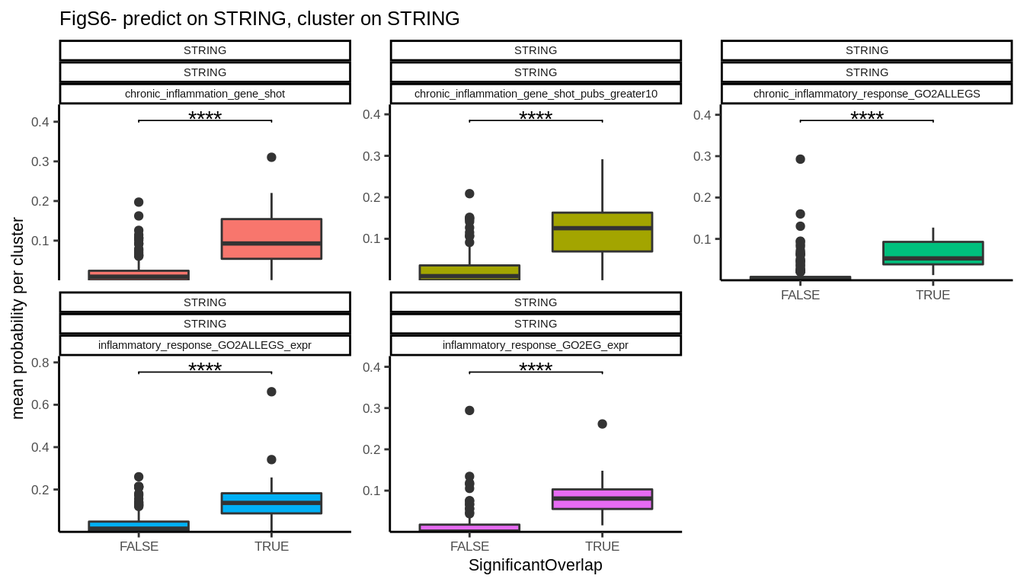

The top network is the network used for Geneplexsus prediction, the bottom network was used for clustering

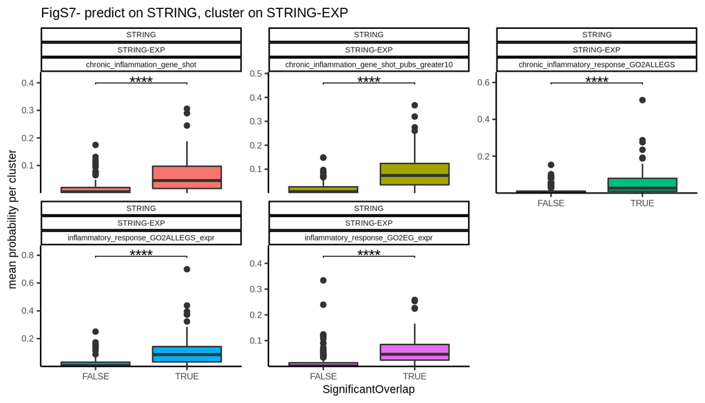

The top network is the network used for Geneplexsus prediction, the bottom network was used for clustering

```r
n = 5
for(cg in c("STRING", "STRING-EXP")){

n = n + 1

plot_p =
  pred_mean_wilcox %>%
  filter(PredictionNetwork == "STRING",
         ClusterGraph == cg)

p1 =
  clust_pred_mean_filt %>%
  filter(PredictionNetwork ==  "STRING",
         ClusterGraph == cg) %>%
  ggplot(aes(x = SignificantOverlap,
             y = MeanProb,
             fill = ChronicInflammationSource)) +
  geom_boxplot() +
  ylab("mean probability per cluster") +
  theme_classic() +
   theme(legend.position="none",
        text = element_text(size = 8),
        strip.text = element_text(size = 5.5),
        strip.text.x = element_text(margin = margin(.1, 0, .1, 0, "cm"))
        ) +
  facet_wrap(~PredictionNetwork + ClusterGraph + ChronicInflammationSource,
             ncol = 3, scales = "free_y") +
  stat_pvalue_manual(plot_p, label = "p.adj.signif", tip.length = 0.01) +
  scale_y_continuous(expand = expansion(mult = c(0, 0.1)))

ggsave(p1,
       file = paste0(figure_path,
                     "/FigS", n, "_mean_pred_non_seed_STRING_",cg,".png"),
       width = 7,
       height = 4,
       dpi = 300)

plot(p1 + ggtitle(paste0("FigS", n, "- predict on STRING, cluster on ", cg)))
}
```